# BIGpopA Tutorial

Pedigree cleaning, validation, and parentage assignment from SNP genotype data

Breeding Insight - Josue Chinchilla-Vargas

2026-07-16

# 1 Introduction

This tutorial demonstrates a typical pedigree workflow using the BIGpopA R package, the analytical engine behind Familia, Breeding Insight’s Shiny application for pedigree validation and ancestry assessment. We run three functions in sequence:

- check_ped() — detect and correct structural pedigree errors (duplicates, conflicting trios, inconsistent sex roles, missing parents).
- validate_pedigree() — test parent–offspring trios for Mendelian errors against SNP genotypes and flag incorrect assignments.
- find_parentage() — assign the most likely parent(s) to progeny from a pool of candidate parents.

It also estimates genome-wide breed/line composition for diploid and polyploid populations with allele_freq_poly() and solve_composition_poly(), shown at the end.

The methods are species-agnostic and apply to a wide range of plant and animal breeding programs.

## 1.1 Install

- It requires R version superior to 4.4.0

Install BIGpopA from CRAN (if not already installed):

```r
install.packages("BIGpopA")
```

# 2 Input data

BIGpopA uses a small toy dataset that exercises every result category. Each function accepts a file path or a data.frame / data.table; to keep this vignette self-contained we build the objects inline: a pedigree, a SNP genotype matrix coded 0/1/2, and candidate parent / progeny lists.

```r
library(BIGpopA)

# SNP genotypes coded 0/1/2 (NA = missing); C_low is mostly missing
genotypes = data.frame(
  id    = c("M1","F1","M2","F2","C1","C2","C3","C_bad","C_low"),
  snp01 = c(  0,   0,   2,   2,   0,   2,   1,     0,     NA),
  snp02 = c(  0,   0,   2,   0,   0,   1,   0,     0,     NA),
  snp03 = c(  0,   2,   0,   2,   1,   1,   1,     1,     NA),
  snp04 = c(  0,   2,   0,   0,   1,   0,   0,     1,     NA),
  snp05 = c(  2,   0,   1,   1,   1,   1,   1,     1,     NA),
  snp06 = c(  2,   0,   1,   0,   1,   1,   1,     1,     NA),
  snp07 = c(  2,   2,   0,   1,   2,   0,   2,     2,     NA),
  snp08 = c(  2,   2,   2,   2,   2,   2,   2,     2,     NA),
  snp09 = c(  0,   1,   0,   2,   1,   1,   1,     1,      0),
  snp10 = c(  0,   1,   2,   0,   0,   1,   0,     0,      0),
  snp11 = c(  2,   1,   1,   2,   1,   2,   2,     1,      2),
  snp12 = c(  2,   1,   0,   1,   2,   1,   1,     2,      2),
  stringsAsFactors = FALSE
)

# pedigree with founders coded 0, a mis-assigned trio (C_bad),
# and a duplicated row (C_missing)
pedigree = data.frame(
  id            = c("M1","F1","M2","F2","C1","C2","C3","C_bad","C_low","C_missing","C_missing"),
  male_parent   = c("0", "0", "0", "0", "M1","M2","M1","M2",   "M1",   "M1",       "M1"),
  female_parent = c("0", "0", "0", "0", "F1","F2","F2","F1",   "F1",   "F1",       "F1"),
  stringsAsFactors = FALSE
)

# candidate parents (with sex) and progeny to assign
parents = data.frame(
  id  = c("M1","M2","F1","F2"),
  sex = c("M", "M", "F", "F"),
  stringsAsFactors = FALSE
)

progeny = data.frame(
  id = c("C1","C2","C3","C_bad","C_low","C_missing"),
  stringsAsFactors = FALSE
)

pedigree
```

| id | male_parent | female_parent |
| --- | --- | --- |
| M1 | 0 | 0 |
| F1 | 0 | 0 |
| M2 | 0 | 0 |
| F2 | 0 | 0 |
| C1 | M1 | F1 |
| C2 | M2 | F2 |
| C3 | M1 | F2 |
| C_bad | M2 | F1 |
| C_low | M1 | F1 |
| C_missing | M1 | F1 |

[output cut: 1 more lines]

```r
genotypes
```

| id | snp01 | snp02 | snp03 | snp04 | snp05 | snp06 | snp07 | snp08 | snp09 | snp10 | snp11 | snp12 |
| --- | --- | --- | --- | --- | --- | --- | --- | --- | --- | --- | --- | --- |
| M1 | 0 | 0 | 0 | 0 | 2 | 2 | 2 | 2 | 0 | 0 | 2 | 2 |
| F1 | 0 | 0 | 2 | 2 | 0 | 0 | 2 | 2 | 1 | 1 | 1 | 1 |
| M2 | 2 | 2 | 0 | 0 | 1 | 1 | 0 | 2 | 0 | 2 | 1 | 0 |
| F2 | 2 | 0 | 2 | 0 | 1 | 0 | 1 | 2 | 2 | 0 | 2 | 1 |
| C1 | 0 | 0 | 1 | 1 | 1 | 1 | 2 | 2 | 1 | 0 | 1 | 2 |
| C2 | 2 | 1 | 1 | 0 | 1 | 1 | 0 | 2 | 1 | 1 | 2 | 1 |
| C3 | 1 | 0 | 1 | 0 | 1 | 1 | 2 | 2 | 1 | 0 | 2 | 1 |
| C_bad | 0 | 0 | 1 | 1 | 1 | 1 | 2 | 2 | 1 | 0 | 1 | 2 |
| C_low | NA | NA | NA | NA | NA | NA | NA | NA | 0 | 0 | 2 | 2 |

The pedigree has four founders (M1, F1, M2, F2, both parents coded 0) and several crosses, including a deliberately duplicated row (C_missing), a mis-assigned trio (C_bad), and a sample with mostly missing genotypes (C_low).

# 3 Pedigree cleaning

check_ped() operates on the pedigree columns id, male_parent, female_parent. Exact duplicates and missing parents are always corrected; conflicting trios and inconsistent sex roles are corrected by default. Cycles are reported only and must be resolved manually. Set verbose = TRUE to print a full report to the console.

```r
#check_ped
clean_ped_results = check_ped(pedigree, verbose = FALSE)

# the corrected, analysis-ready pedigree
clean_ped = clean_ped_results$corrected_pedigree
clean_ped
```

| id | male_parent | female_parent |
| --- | --- | --- |
| M1 | 0 | 0 |
| F1 | 0 | 0 |
| M2 | 0 | 0 |
| F2 | 0 | 0 |
| C1 | M1 | F1 |
| C2 | M2 | F2 |
| C3 | M1 | F2 |
| C_bad | M2 | F1 |
| C_low | M1 | F1 |
| C_missing | M1 | F1 |

The returned list also exposes per-issue tables for review, e.g. clean_ped_results$exact_duplicates (here, the repeated C_missing row) and clean_ped_results$missing_parents.

# 4 Pedigree validation

validate_pedigree() compares each trio against the genotype matrix and computes a Mendelian error rate. Trios are classified as pass, fail, low_markers, no_genotype_data, founders, or missing_parents, and a best-matching replacement parent is suggested where relevant. With plot_results = TRUE the function draws a histogram of trio error percentages.

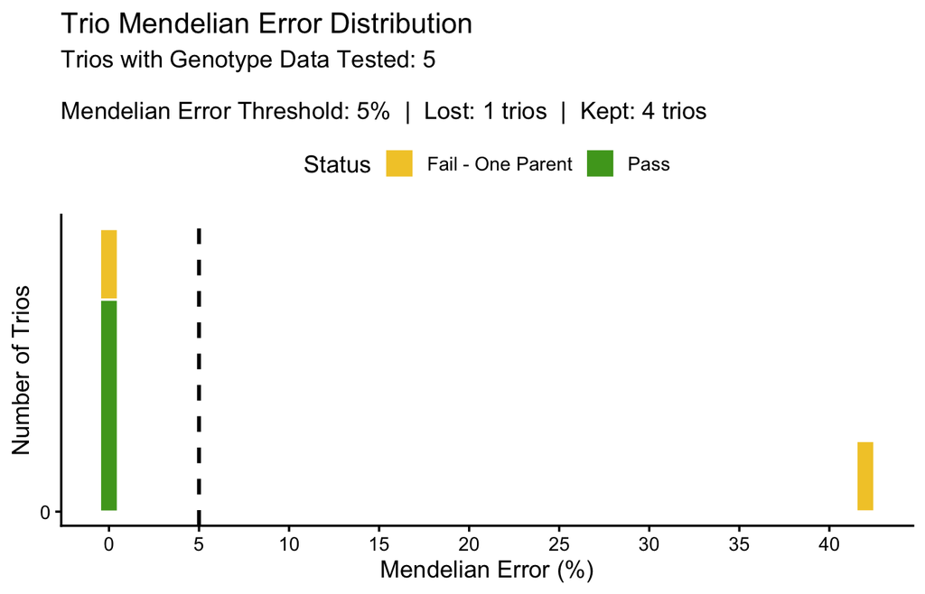

```r
#validate_ped
ped_validate_results = validate_pedigree(clean_ped, genotypes,
                                         verbose = FALSE, plot_results = TRUE)
```

```r
ped_validate_report = ped_validate_results$full_results
ped_validate_report
```

| id | orig_male_parent | orig_female_parent | trio_mendelian_error_pct | trio_markers_tested | status | recommended_correction | male_parent_hom_error_pct | female_parent_hom_error_pct | best_male_candidate | best_male_candidate_error_pct | best_female_candidate | best_female_candidate_error_pct |
| --- | --- | --- | --- | --- | --- | --- | --- | --- | --- | --- | --- | --- |
| M1 | 0 | 0 | NA | 0 | missing_both_parents | none | NA | NA | C1 | 0 | C3 | 0.00 |
| F1 | 0 | 0 | NA | 0 | missing_both_parents | none | NA | NA | C1 | 0 | C_bad | 0.00 |
| M2 | 0 | 0 | NA | 0 | missing_both_parents | none | NA | NA | C2 | 0 | M1 | 55.56 |
| F2 | 0 | 0 | NA | 0 | missing_both_parents | none | NA | NA | C2 | 0 | C3 | 0.00 |
| C1 | M1 | F1 | 0.00 | 12 | pass | none | NA | NA | NA | NA | NA | NA |
| C2 | M2 | F2 | 0.00 | 12 | pass | none | NA | NA | NA | NA | NA | NA |
| C3 | M1 | F2 | 0.00 | 12 | pass | none | NA | NA | NA | NA | NA | NA |
| C_bad | M2 | F1 | 41.67 | 12 | fail | remove_male_parent | 83.33 | 0 | M1 | 0 | NA | NA |
| C_low | M1 | F1 | 0.00 | 4 | low_markers | low_markers_remove_female_parent | 0.00 | NA | NA | NA | C1 | 0.00 |
| C_missing | M1 | F1 | NA | 0 | no_genotype_data | none | NA | NA | NA | NA | NA | NA |

Reading the status column: C1, C2, C3 pass; C_bad fails (its recorded male parent shows a high homozygous-mismatch rate, so the recommended correction is to remove it); C_low is flagged low_markers because too few markers were genotyped; and C_missing has no_genotype_data. Key tuning arguments are trio_error_threshold (default 5.0), min_markers (default 10), and single_parent_error_threshold (default 2.0).

# 5 Parentage assignment

When parentage is unknown, find_parentage() searches a pool of candidate parents for the best assignment to each progeny. The method argument selects the search: best_pair (default), best_male_parent, best_female_parent, or best_match.

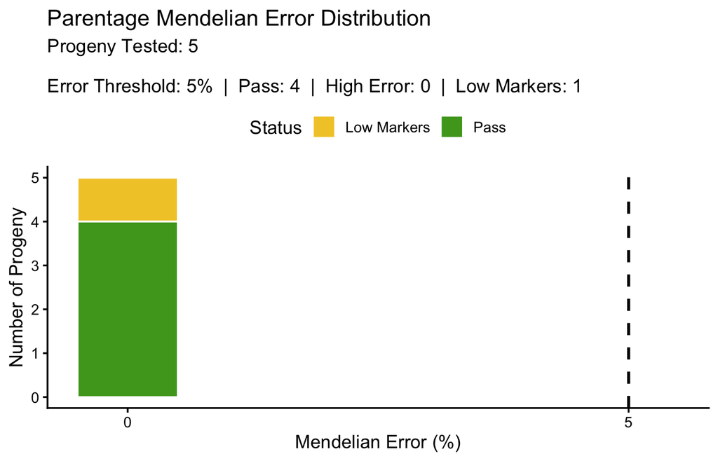

```r
#find_parentage
find_parentage_results = find_parentage(genotypes, parents, progeny,
                                        method = "best_pair",
                                        verbose = FALSE, plot_results = TRUE)
```

```r
find_parentage_report = find_parentage_results$full_results
find_parentage_report
```

| id | male_parent | female_parent | mendelian_error_pct | markers_tested | status |
| --- | --- | --- | --- | --- | --- |
| C1 | M1 | F1 | 0.00 | 12 | pass |
| C2 | M2 | F2 | 0.00 | 12 | pass |
| C3 | M1 | F2 | 0.00 | 12 | pass |
| C_bad | M1 | F1 | 0.00 | 12 | pass |
| C_low | M1 | F1 | 0.00 | 4 | low_markers |

Each progeny is assigned the pair minimizing Mendelian error and labelled pass, high_error, or low_markers. Notice that C_bad, which failed validation against its recorded parents, is here correctly recovered to its true pair (M1/F1) at 0% error, while C_low remains low_markers. Useful arguments include error_threshold, min_markers, show_ties, allow_parent_selfing, and exclude_self_match.

# 6 Breed and line composition

Beyond pedigree QC, BIGpopA estimates genome-wide breed or line composition for diploid and polyploid populations using a breedTools-style quadratic programming approach (Funkhouser et al. 2017). This example mirrors a blueberry (autotetraploid, ploidy = 4) analysis that assigns validation samples to two cultivar reference panels, Jewel and Draper.

The workflow has two steps: compute reference-panel allele frequencies with allele_freq_poly(), then estimate each validation sample’s composition with solve_composition_poly().

```r
library(dplyr)

# reference genotypes: individuals x SNPs, tetraploid dosage of allele B (0..4)
reference = data.frame(
  S1 = c(0, 1, 0, 4, 3, 4),
  S2 = c(1, 0, 0, 3, 4, 4),
  S3 = c(0, 1, 1, 4, 3, 3),
  S4 = c(1, 0, 1, 3, 4, 3),
  S5 = c(0, 1, 0, 4, 3, 4),
  S6 = c(1, 0, 1, 3, 4, 3),
  row.names = c("Jewel1","Jewel2","Jewel3","Draper1","Draper2","Draper3")
)

# reference panel membership (which individuals define each cultivar)
ref_ids = list(
  Jewel  = c("Jewel1","Jewel2","Jewel3"),
  Draper = c("Draper1","Draper2","Draper3")
)

# allele frequencies of the reference panels (SNPs x panels)
freq = allele_freq_poly(reference, ref_ids, ploidy = 4)
freq
```

```
##         Jewel    Draper
## S1 0.08333333 0.9166667
## S2 0.08333333 0.9166667
## S3 0.16666667 0.8333333
## S4 0.16666667 0.8333333
## S5 0.08333333 0.9166667
## S6 0.16666667 0.8333333
```

```r
# validation samples to assign: samples x SNPs (same SNPs as the reference)
validation = data.frame(
  S1 = c(0, 4, 2),
  S2 = c(1, 3, 2),
  S3 = c(0, 4, 2),
  S4 = c(1, 3, 2),
  S5 = c(0, 4, 2),
  S6 = c(1, 3, 2),
  row.names = c("Sample1","Sample2","Sample3")
)

# breed/line composition (panel columns plus an R2 model-fit column)
prediction = as.data.frame(solve_composition_poly(validation, freq, ploidy = 4))
prediction
```

|  | Jewel | Draper | R2 |
| --- | --- | --- | --- |
| Sample1 | 1.000000e+00 | 2.408405e-16 | 0.1111111 |
| Sample2 | 4.834614e-16 | 1.000000e+00 | 0.1111111 |
| Sample3 | 5.000000e-01 | 5.000000e-01 | NA |

It is important to note that while the model produces an R2 value, it is expected to be low since an allele dosage (discrete number) is being regressed on an allele frequency (continuous value).

Assign each sample to the cultivar with the highest composition (ignoring the R2 fit column) and format the panel columns as percentages:

```r
line_cols = setdiff(names(prediction), "R2")

pred_results = prediction %>%
  mutate(
    ID             = rownames(prediction),
    predicted_line = line_cols[max.col(as.matrix(prediction[line_cols]), ties.method = "first")],
    across(all_of(line_cols), ~ scales::percent(., accuracy = 0.1))
  ) %>%
  select(ID, predicted_line, all_of(line_cols))

pred_results
```

|  | ID | predicted_line | Jewel | Draper |
| --- | --- | --- | --- | --- |
| Sample1 | Sample1 | Jewel | 100.0% | 0.0% |
| Sample2 | Sample2 | Draper | 0.0% | 100.0% |
| Sample3 | Sample3 | Jewel | 50.0% | 50.0% |

Sample1 is assigned Jewel and Sample2 Draper (each essentially 100%), while the admixed Sample3 splits roughly evenly between them. For diploid data set ploidy = 2. Save the table with write.table(pred_results, “composition.txt”, sep = “, row.names = FALSE).

# 7 Complete workflow

```r
# pedigree quality control
clean_ped = check_ped(pedigree)$corrected_pedigree
validated = validate_pedigree(clean_ped, genotypes)$full_results
assigned  = find_parentage(genotypes, parents, progeny, method = "best_pair")$full_results

# breed/line composition
freq       = allele_freq_poly(reference, ref_ids, ploidy = 4)
prediction = solve_composition_poly(validation, freq, ploidy = 4)
```

# 9 How to cite

If you use BIGpopA in research, run citation(“BIGpopA”) for the current reference.

```r
citation("BIGpopA")
```

```
##
##   Chinchilla-Vargas J, Sandercock A, of Florida U (2026). _BIGpopA:
##   Pedigree Validation Genetic Composition of Diploids & Polyploids_. R
##   package version 1.0.6, <https://github.com/Breeding-Insight/BIGpopA>.
##
## A BibTeX entry for LaTeX users is
##
##   @Manual{,
##     title = {BIGpopA: Pedigree Validation Genetic Composition of Diploids & Polyploids},
##     author = {Josue Chinchilla-Vargas and Alexander Sandercock and University {of Florida}},
##     year = {2026},
##     note = {R package version 1.0.6},
##     url = {https://github.com/Breeding-Insight/BIGpopA},
##   }
```

# 10 Acknowledgments

Developed as part of the [Breeding Insight](https://www.breedinginsight.org) initiative to provide open-source, data-driven tools for modern breeding programs.